# Chapter 1

L. Ricolfi

2022-11-25

# 1 Intro

**Project title:** PFAS exposure of humans, animals and environmental compartments: an evidence review map and bibliometric analysis

In this document I provide the results of my Evidence Review Map (Chapter 1 of my thesis) The results are organized in 3 objectives.

# 2 Project’s objectives

- **Objective 1.** Mapping: What evidence on PFAS has been synthesized? I aim to reveal what areas in the realm of PFAS health-related and environmental research have been synthesized the most and where syntheses of evidence are lacking.
- **Objective 2.** Critical appraisal: How robust are syntheses of PFAS evidence? I will examine the included syntheses for their reporting quality and potential biases, in order to assess reliability of reviews’ conclusions, reveal syntheses that should be re-done, and highlight the aspects of review methodology that need to be improved.
- **Objective 3.** Bibliometrics: How is synthesized PFAS evidence connected? I will examine which countries and institutions are mostly involved in secondary PFAS research and what do the networks between these institutions look like.

```r
knitr::opts_chunk$set(echo = FALSE, message = FALSE, warning = FALSE)
```

# 3 Table of included reviews

The following table is a list of all included reviews

Table of included studies

| Study_ID | Author_year | Paper_title |
| --- | --- | --- |
| S_001 | Johnson_2014 | The Navigation Guide—Evidence-Based Medicine Meets Environmental Health: Systematic Review of Human Evidence for PFOA Effects on Fetal Growth |
| S_002 | Winkens_2017 | Early life exposure to per- and polyfluoroalkyl substances (PFASs): A critical review |
| S_003 | Stanifer_2018 | Perfluorinated Chemicals as Emerging Environmental Threats to Kidney Health - A Scoping Review |
| S_004 | Ballesteros_2017 | Exposure to perfluoroalkyl substances and thyroid function in pregnant women and children: A systematic review of epidemiologic studies |
| S_005 | Caserta_2011 | Environment and women’s reproductive health |
| S_006 | Mohanto_2021 | Life-Time Environmental Chemical Exposure and Obesity: Review of Epidemiological Studies Using Human Biomonitoring Methods |
| S_008 | Liu_2018 | Perfluorooctanoic Acid (PFOA) Exposure in Early Life Increases Risk of Childhood Adiposity: A Meta-Analysis of Prospective Cohort Studies |
| S_009 | Jensen_2019 | Endocrine disrupters, semen quality and anogenital distance |
| S_010 | Wambaugh_2013 | Dosimetric Anchoring of In Vivo and In Vitro Studies for Perfluorooctanoate and Perfluorooctanesulfonate |
| S_011 | Picó_2011 | Perfluorinated Compounds in Food: A Global Perspective |
| S_012 | Moore_2022 | The Association between ADHD and Environmental Chemicals—A Scoping Review |
| S_013 | Gascon_2013 | Effects of persistent organic pollutants on the developing respiratory and immune systems: A systematic review |
| S_014 | Cao_2021 | The relationship between maternal perfluoroalkylated substances exposure and low birth weight of offspring: a systematic review and meta-analysis |
| S_015 | Sanganyado_2021 | Organic pollutants in deep sea: Occurrence, fate, and ecological implications |
| S_016 | Rocha_2021 | Exposure to endocrine disruptors and risk of breast cancer: A systematic review |
| S_017 | Hitchcock_2019 | Effects of Maternal Reproductive Investment on Sex-Specific Pollutant Accumulation in Seabirds: A Meta-Analysis |
| S_018 | DeLuca_2022 | Human exposure pathways to poly- and perfluoroalkyl substances (PFAS) from indoor media: A systematic review |
| S_019 | Guo_2022 | Non-targeted metabolomics and associations with per- and polyfluoroalkyl substances (PFAS) exposure in humans: A scoping review |
| S_020 | Wang_2022 | Association between per- and polyfluoroalkyl substances and risk of gestational diabetes mellitus |
| S_021 | Yang_2021 | Associations between exposure to perfluoroalkyl substances and birth outcomes: A meta-analysis |
| S_022 | Kurwadkar_2021 | Per- and polyfluoroalkyl substances in water and wastewater: A critical review of their global occurrence and distribution |
| S_023 | Balaguer-Trias_2022 | Impact of Contaminants on Microbiota: Linking the Gut–Brain Axis with Neurotoxicity |
| S_024 | Sun_2022 | Prenatal exposure to endocrine-disrupting chemicals and thyroid function in neonates: A systematic review and meta-analysis |
| S_025 | Appel_2022 | The transplacental transfer efficiency of per- and polyfluoroalkyl substances (PFAS): a first meta-analysis |
| S_026 | Stratakis_2021 | Prenatal exposure to persistent organic pollutants and childhood obesity: A systematic review and meta-analysis of human studies |
| S_027 | Li_2022 | Exposure routes, bioaccumulation and toxic effects of per- and polyfluoroalkyl substances (PFASs) on plants: A critical review |
| S_028 | Grobin_2022 | Multi-parameter risk assessment of forty-one selected substances with endocrine disruptive properties in surface waters worldwide |
| S_029 | Haverinen_2021 | Metabolic Syndrome and Endocrine Disrupting Chemicals: An Overview of Exposure and Health Effects |
| S_030 | Močnik_2021 | Obesogens in Children—An Uncharted Territory |
| S_031 | Bräuner_2021 | Endocrine Disrupting Chemicals and Risk of Testicular Cancer: A Systematic Review and Meta-analysis |

[output cut: 143 more lines]

# 4 Objective 1

**Mapping**: What evidence on PFAS has been synthesized?

Here we aim to reveal what areas in the realm of PFAS health-related and environmental research have been synthesized the most and where syntheses of evidence are lacking.

## 4.1 PFAS focus

The following graph answers the questions: - How many reviews are focused on PFAS and how many are not? - How many reviews review one type of PFAS and how many review multiple types?

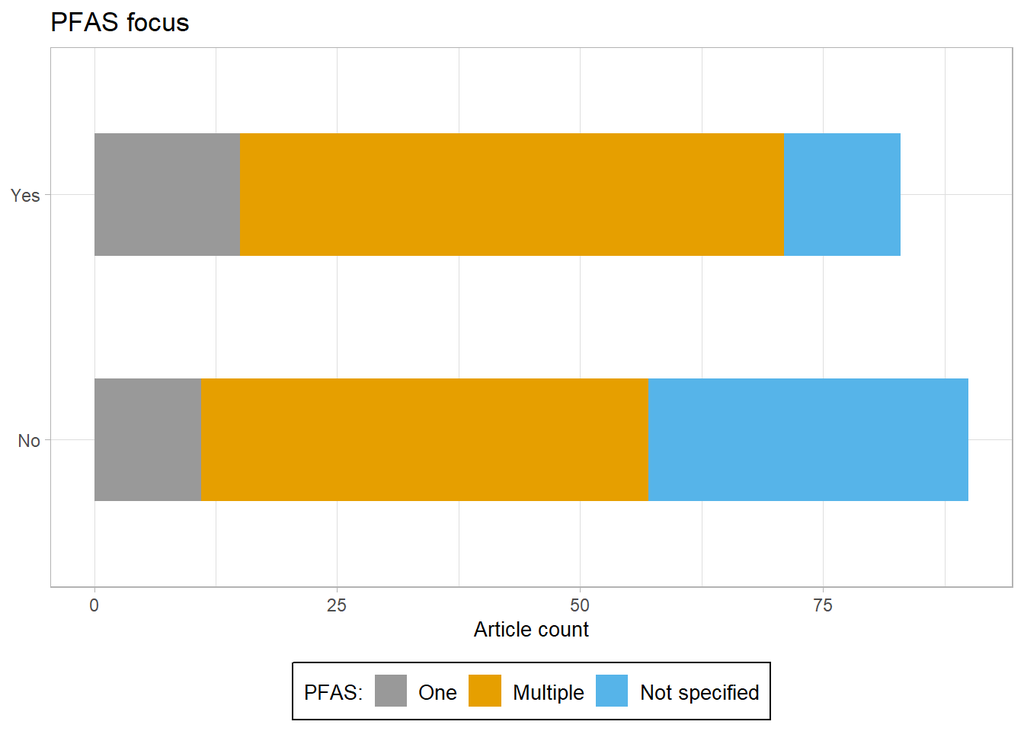

## 4.2 PFAS types

What types of PFAS are reviewed the most?

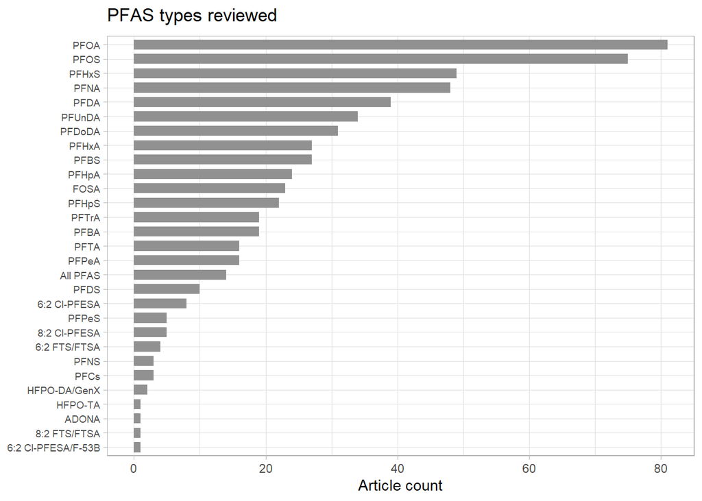

## 4.3 Main review topics (MeSH terms)

What are the top 10 MeSH headings reviewed?

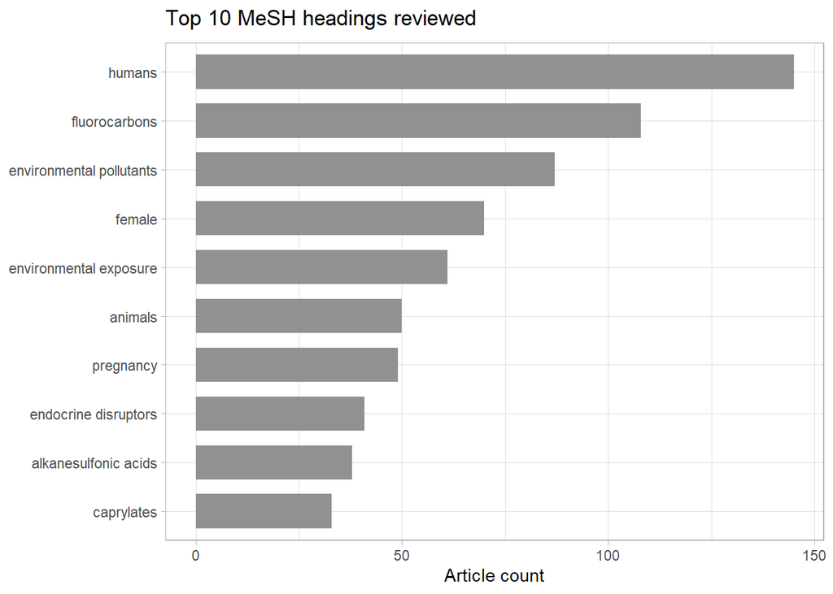

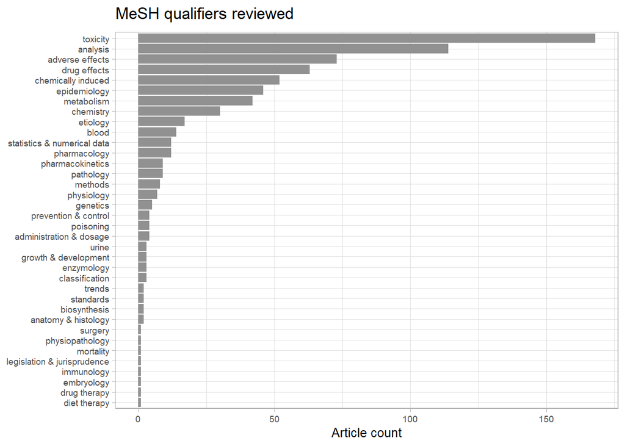

## 4.4 Main review subjects

What are the subjects reviwed the most?

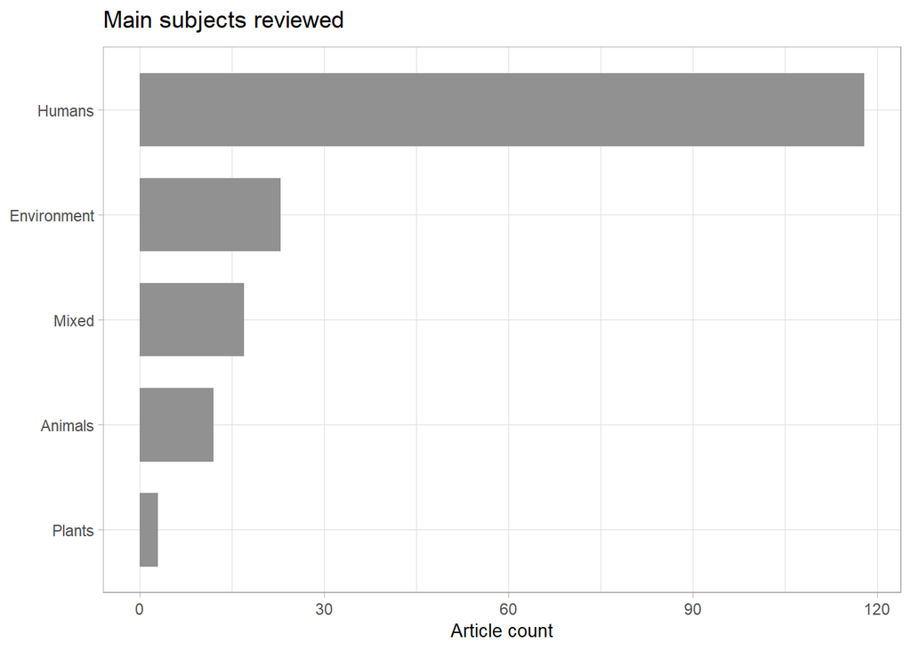

## 4.5 Combining MeSH qualifiers with main review subjects

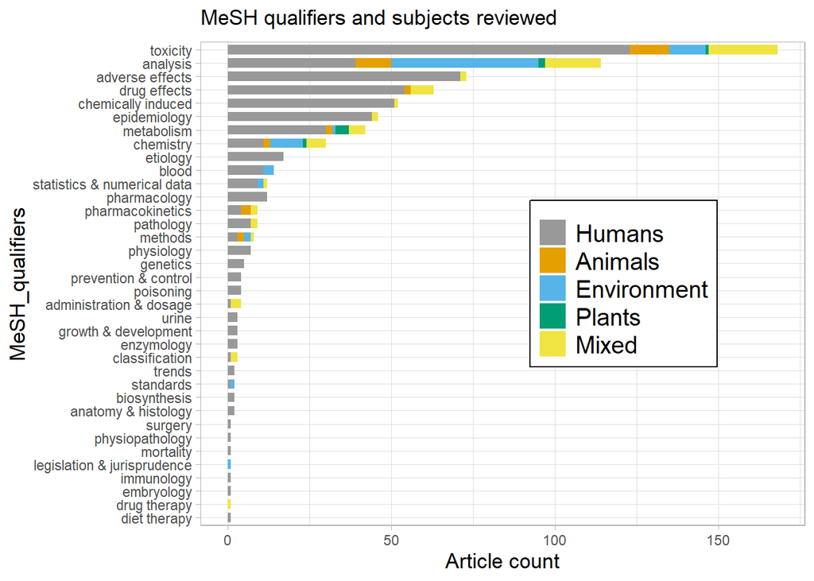

## 4.6 PFAS focus by main review subject

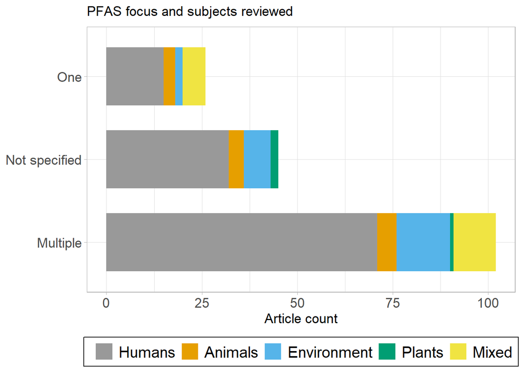

## 4.7 PFAS types by main review subject

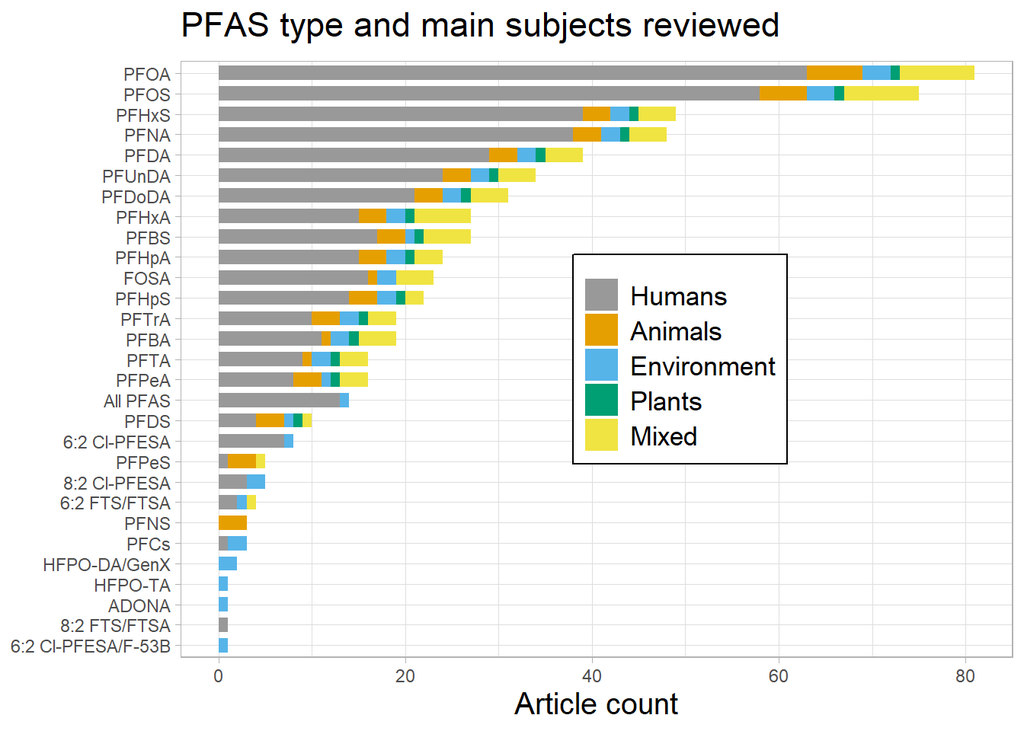

## 4.8 Animal species reviewed

**Work in progress**

[figure not shown]

## 4.9 Species vs PFAS focus

**Work in progress**

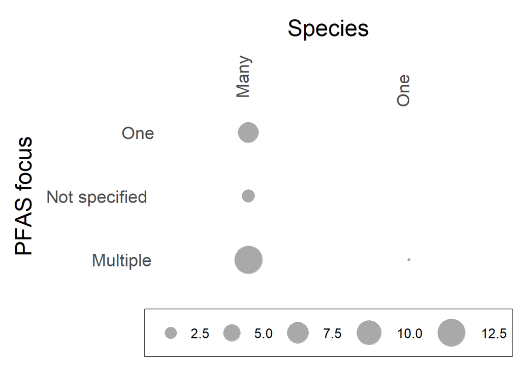

## 4.10 Time-trends

What is the trend of number of publications?

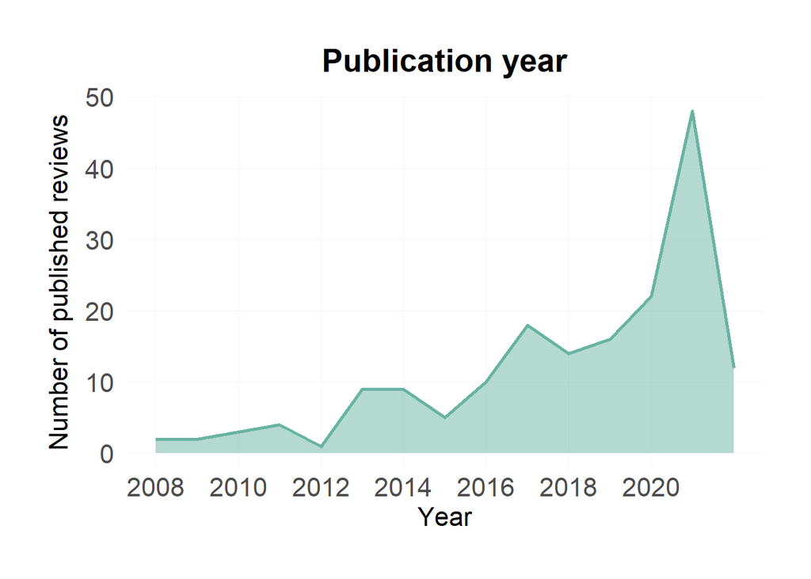

# 5 Objective 2

**Critical appraisal**: How robust are syntheses of PFAS evidence?

Here we will examine the included syntheses for their reporting quality and potential biases, in order to assess reliability of reviews’ conclusions, reveal syntheses that should be re-done, and highlight the aspects of review methodology that need to be improved.

The following table shows the AMSTAR2 questions and the lables for plotting

Table. List of AMSTAR2 questions with labels for plotting

| questions | label |
| --- | --- |
| Q1. Are the research questions and inclusion criteria for the review clearly delineated? | question and criteria |
| Q2. Did the report of the review contain an explicit statement that the review methods were established prior to the conduct of the review and did the report justify any significant deviations from th… | a priori protocol |
| Q3. Did the review authors explain their selection of the study designs for inclusion in the review? | included study designs |
| Q4. Did the review authors use a comprehensive literature search strategy? | comprehensive search |
| Q5. Did the review authors perform study selection in duplicate? | selection duplicated |
| Q6. Did the review authors perform data extraction in duplicate? | extraction duplicated |
| Q7. Did the review authors provide a list of excluded studies and justify the exclusions? | list of excluded studies |
| Q8. Did the review authors describe the included studies in adequate detail? | summary of included studies |
| Q9. Did the review authors use a satisfactory technique for assessing the risk of bias (RoB) in individual studies that were included in the review? | critical appraisal |
| Q10. Did the review authors report on the sources of funding for the studies included in the review? | sources of funding |
| Q11. If meta-analysis was performed did the review authors use appropriate methods for statistical combination of results? | quantitative synthesis |
| Q12. If meta-analysis was performed, did the review authors assess the potential impact of RoB in individual studies on the results of the meta-analysis or other evidence synthesis? | risk of bias |
| Q13. Did the review authors account for RoB in individual studies when interpreting/ discussing the results of the review? | effect of bias |
| Q14. Did the review authors provide a satisfactory explanation for, and discussion of, any heterogeneity observed in the results of the review? | variability investigated |
| Q15. If they performed quantitative synthesis did the review authors carry out an adequate investigation of publication bias (small study bias) and discuss its likely impact on the results of the revi… | publication bias |
| Q16. Did the review authors report any potential sources of conflict of interest, including any funding they received for conducting the review? | conflict of interest |

## 5.1 Summary plot

AMSTAR2 assessment results as percentages of each answer score per question.

```
## [1] 107  36
```

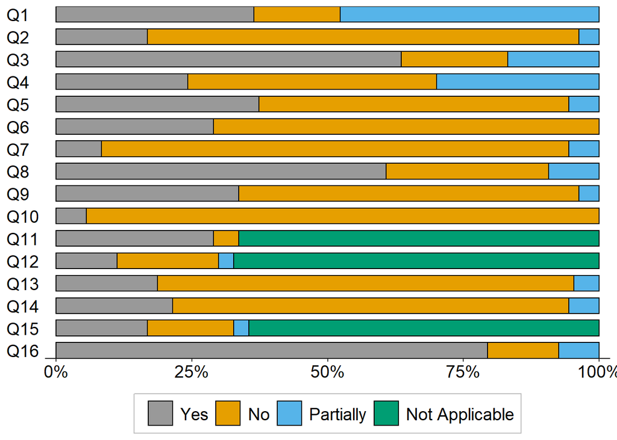

## 5.2 Individual scores plot

AMSTAR2 assessment results as a score per article per question.

```
## [1] 107  36
```

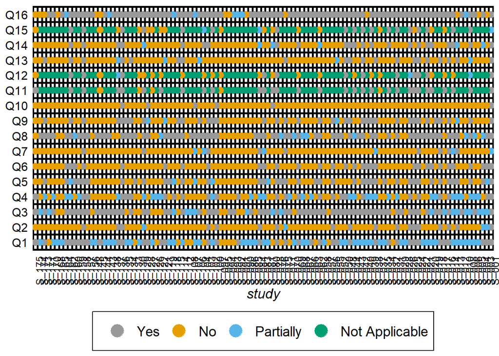

## 5.3 COI statement

Whether Conflict Of Interests statement is provided for individual reviews.

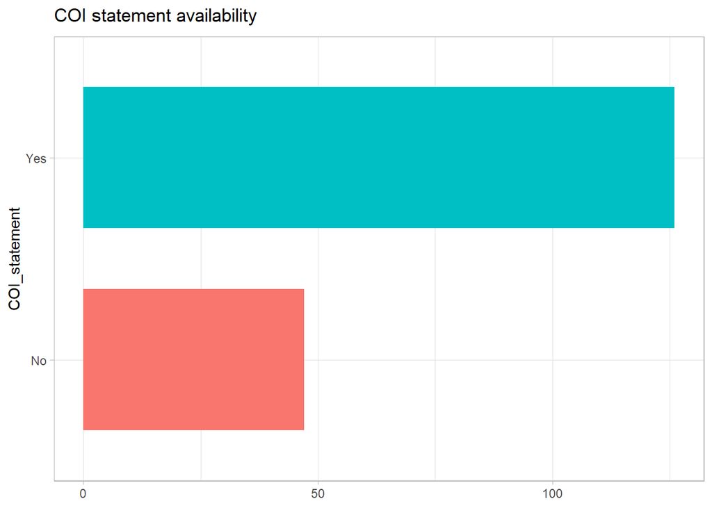

## 5.4 COI present

Whether potential Conflict Of Interests is acknowledged for individual reviews.

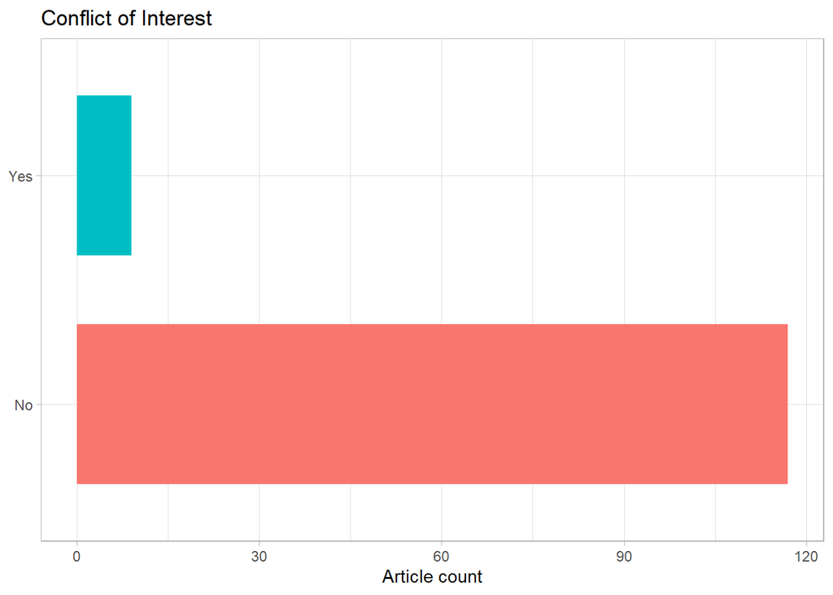

## 5.5 Funding statement

Whether funding statement is provided for individual reviews.

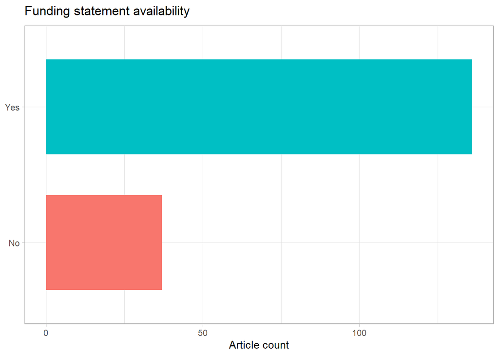

## 5.6 Non-profit funding acknowledged

Whether funding from non-profit (NGO, government, universities, etc.) is acknowledged for individual reviews.

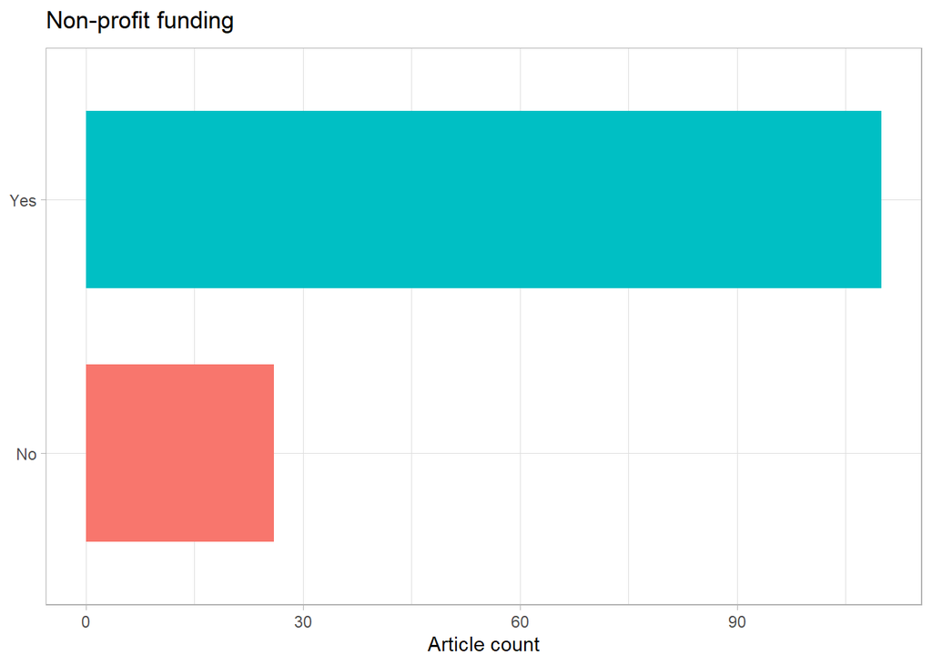

## 5.7 Industry funding acknowledged

Whether funding from industry (including government-industry collaborations) is acknowledged for individual reviews.

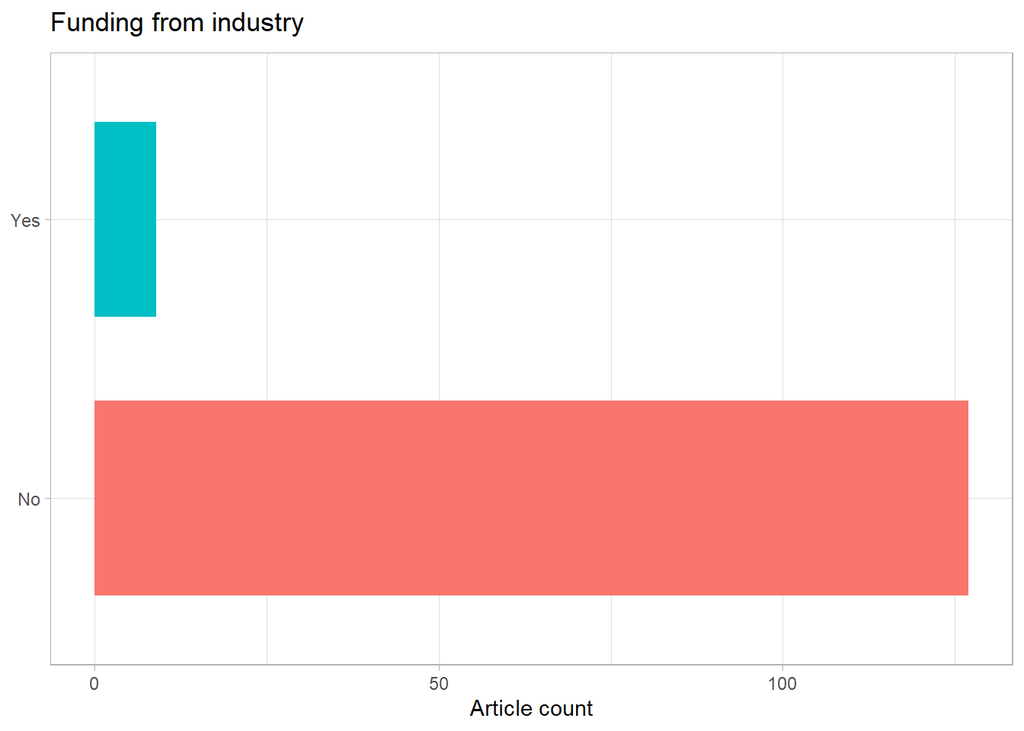

## 5.8 Data availability

Whether extracted data is made available for individual reviews.

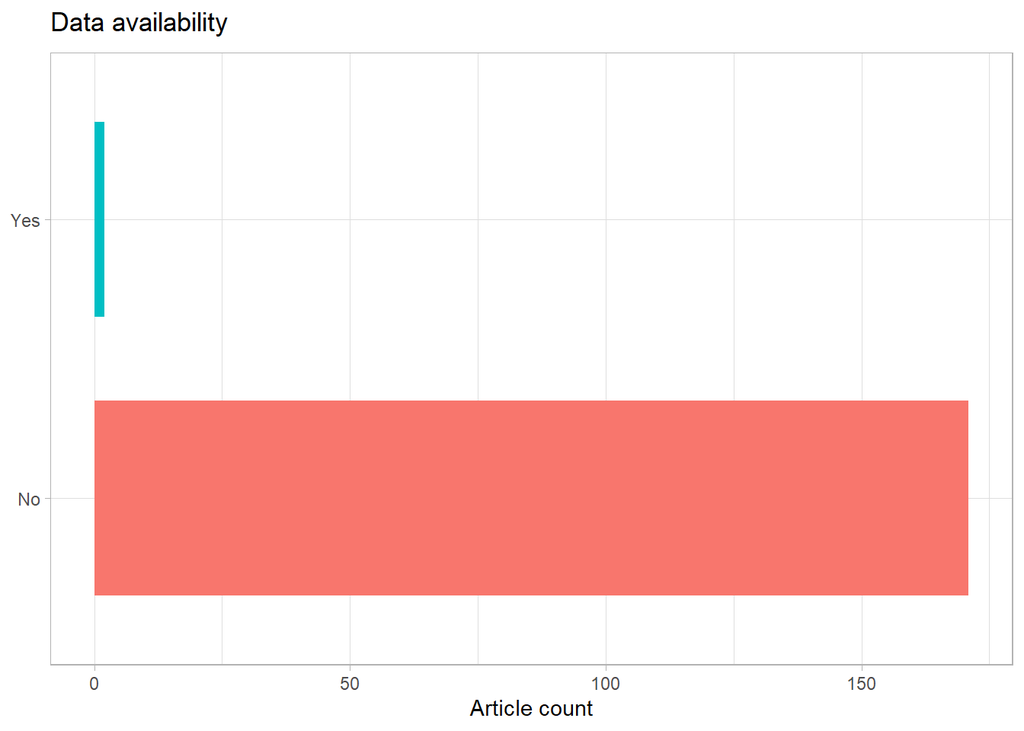

## 5.9 Code availability

Whether code for analyses is made available for individual reviews.

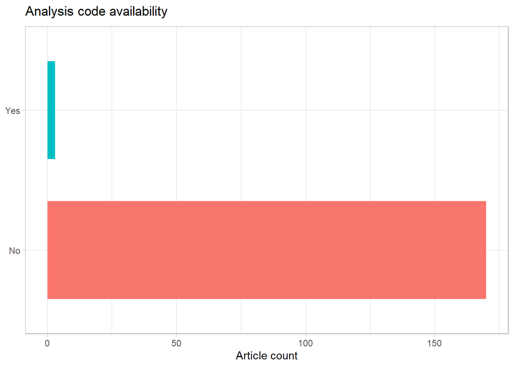

# 6 Objective 3

**Bibliometrics**: How is synthesized PFAS evidence connected?

## 6.1 Circular plot 1

The following plot shows the network of collaborations among and within countries

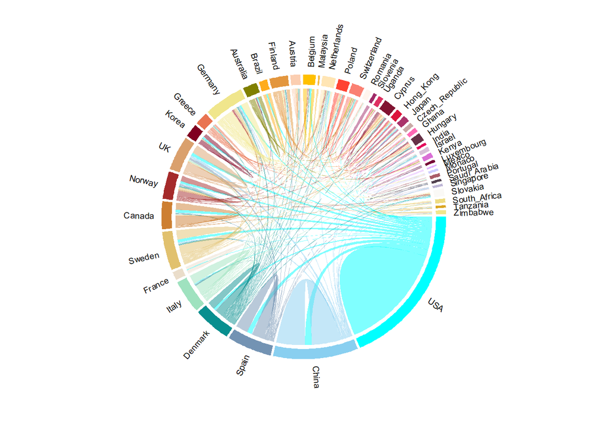

## 6.2 Circular plot 2

The following plot is the same of the previous one but with less countries - it only shows the most active countries

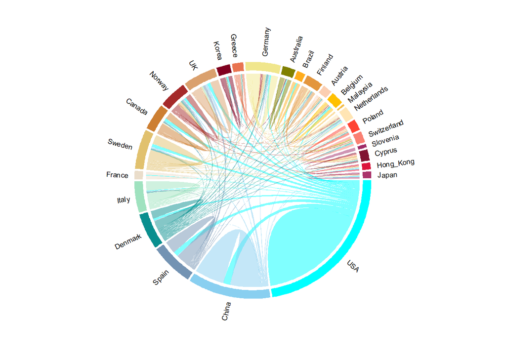

## 6.3 Circular plot 3

The following plot shows the network of collaborations among in countries - collaboration within the same country removed

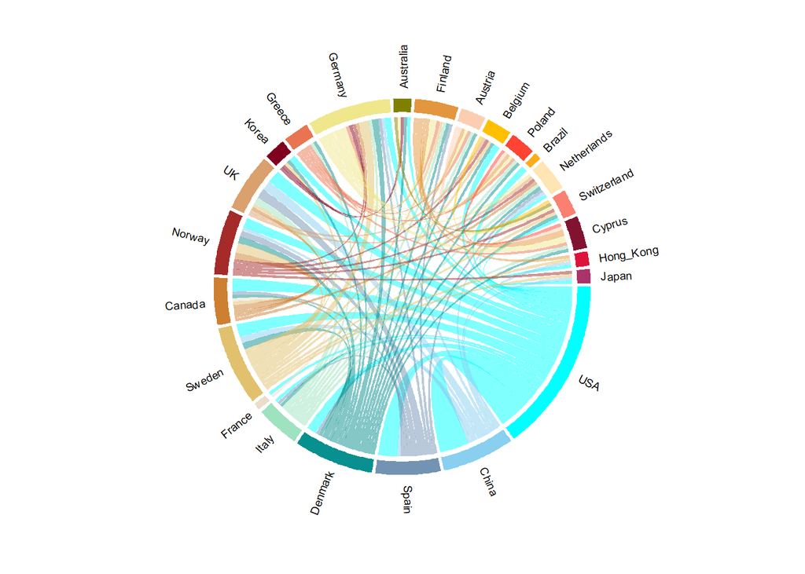

[output not shown]

[output cut: 400 more lines]